# Lab 7

[GitHub Repository](https://github.com/pinoliar/GSB_544)

```python
import pandas as pd
import numpy as np
import matplotlib.pyplot as plt
from sklearn.model_selection import train_test_split, cross_val_score, GridSearchCV
from sklearn.preprocessing import StandardScaler
from sklearn.neighbors import KNeighborsClassifier
from sklearn.linear_model import LogisticRegression
from sklearn.tree import DecisionTreeClassifier
from sklearn.metrics import confusion_matrix, roc_auc_score, roc_curve, make_scorer
from sklearn.pipeline import Pipeline
df = pd.read_csv("/Users/pinoliara/Downloads/GSB_544/Week_8/heart_attack.csv")
```

```python
df.head()
```

|  | age | sex | cp | trtbps | chol | restecg | thalach | output |
| --- | --- | --- | --- | --- | --- | --- | --- | --- |
| 0 | 63 | 1 | 3 | 145 | 233 | 0 | 150 | 1 |
| 1 | 37 | 1 | 2 | 130 | 250 | 1 | 187 | 1 |
| 2 | 56 | 1 | 1 | 120 | 236 | 1 | 178 | 1 |
| 3 | 57 | 0 | 0 | 120 | 354 | 1 | 163 | 1 |
| 4 | 57 | 1 | 0 | 140 | 192 | 1 | 148 | 1 |

```python
df.describe()
```

|  | age | sex | cp | trtbps | chol | restecg | thalach | output |
| --- | --- | --- | --- | --- | --- | --- | --- | --- |
| count | 273.000000 | 273.000000 | 273.000000 | 273.000000 | 273.000000 | 273.000000 | 273.000000 | 273.000000 |
| mean | 54.347985 | 0.673993 | 0.974359 | 132.098901 | 246.860806 | 0.538462 | 149.446886 | 0.534799 |
| std | 9.163134 | 0.469611 | 1.030456 | 17.700358 | 52.569726 | 0.528059 | 23.240707 | 0.499704 |
| min | 29.000000 | 0.000000 | 0.000000 | 94.000000 | 126.000000 | 0.000000 | 71.000000 | 0.000000 |
| 25% | 47.000000 | 0.000000 | 0.000000 | 120.000000 | 211.000000 | 0.000000 | 133.000000 | 0.000000 |
| 50% | 56.000000 | 1.000000 | 1.000000 | 130.000000 | 240.000000 | 1.000000 | 152.000000 | 1.000000 |
| 75% | 61.000000 | 1.000000 | 2.000000 | 140.000000 | 275.000000 | 1.000000 | 166.000000 | 1.000000 |
| max | 77.000000 | 1.000000 | 3.000000 | 200.000000 | 564.000000 | 2.000000 | 202.000000 | 1.000000 |

```python
df.info()
```

```
<class 'pandas.core.frame.DataFrame'>
RangeIndex: 273 entries, 0 to 272
Data columns (total 8 columns):
 #   Column   Non-Null Count  Dtype
---  ------   --------------  -----
 0   age      273 non-null    int64
 1   sex      273 non-null    int64
 2   cp       273 non-null    int64
 3   trtbps   273 non-null    int64
 4   chol     273 non-null    int64
 5   restecg  273 non-null    int64
 6   thalach  273 non-null    int64
 7   output   273 non-null    int64
dtypes: int64(8)
memory usage: 17.2 KB
```

```python
df.isnull().sum()
```

```
age        0
sex        0
cp         0
trtbps     0
chol       0
restecg    0
thalach    0
output     0
dtype: int64
```

```python
df.duplicated().sum()
df = df.drop_duplicates()
df
```

|  | age | sex | cp | trtbps | chol | restecg | thalach | output |
| --- | --- | --- | --- | --- | --- | --- | --- | --- |
| 0 | 63 | 1 | 3 | 145 | 233 | 0 | 150 | 1 |
| 1 | 37 | 1 | 2 | 130 | 250 | 1 | 187 | 1 |
| 2 | 56 | 1 | 1 | 120 | 236 | 1 | 178 | 1 |
| 3 | 57 | 0 | 0 | 120 | 354 | 1 | 163 | 1 |
| 4 | 57 | 1 | 0 | 140 | 192 | 1 | 148 | 1 |
| ... | ... | ... | ... | ... | ... | ... | ... | ... |
| 268 | 59 | 1 | 0 | 164 | 176 | 0 | 90 | 0 |
| 269 | 57 | 0 | 0 | 140 | 241 | 1 | 123 | 0 |
| 270 | 45 | 1 | 3 | 110 | 264 | 1 | 132 | 0 |
| 271 | 68 | 1 | 0 | 144 | 193 | 1 | 141 | 0 |
| 272 | 57 | 0 | 1 | 130 | 236 | 0 | 174 | 0 |

272 rows × 8 columns

Part One: Fitting Models This section asks you to create a final best model for each of the model types studied this week. For each, you should: Find the best model based on ROC AUC for predicting the target variable. Report the (cross-validated!) ROC AUC metric. Fit the final model. Output a confusion matrix; that is, the counts of how many observations fell into each predicted class for each true class. (Where applicable) Interpret the coefficients and/or estimates produced by the model fit. You should certainly try multiple model pipelines to find the best model. You do not need to include the output for every attempted model, but you should describe all of the models explored. You should include any hyperparameter tuning steps in your writeup as well.

```python
X = df.drop("output", axis=1)
y = df["output"]
X_train, X_test, y_train, y_test = train_test_split(X, y, test_size=0.2, stratify=y)
```

Q1: KNN

```python
knn_param_grid = {
    "knn__n_neighbors": [1, 3, 5, 7, 9, 11, 13, 15, 17, 19, 21, 25, 30],
    "knn__metric": ["euclidean", "manhattan"],
    "knn__weights": ["uniform", "distance"]
}

knn_pipeline = Pipeline([
    ("scaler", StandardScaler()),
    ("knn", KNeighborsClassifier())
])

knn_grid = GridSearchCV(knn_pipeline, knn_param_grid, cv=5, scoring="roc_auc")
knn_grid.fit(X_train, y_train)
```

```
GridSearchCV(cv=5,
             estimator=Pipeline(steps=[('scaler', StandardScaler()),
                                       ('knn', KNeighborsClassifier())]),
             param_grid={'knn__metric': ['euclidean', 'manhattan'],
                         'knn__n_neighbors': [1, 3, 5, 7, 9, 11, 13, 15, 17, 19,
                                              21, 25, 30],
                         'knn__weights': ['uniform', 'distance']},
             scoring='roc_auc')
```

```python
knn_grid.best_params_
best_knn = knn_grid.best_estimator_
knn_cv_scores = cross_val_score(best_knn, X_train, y_train, cv=5, scoring="roc_auc")
best_knn.fit(X_train, y_train)
y_pred_knn = best_knn.predict(X_test)
y_pred_proba_knn = best_knn.predict_proba(X_test)[:, 1]
confusion_matrix(y_test, y_pred_knn)
```

```
array([[15, 11],
       [ 3, 26]])
```

Q2: Logistic Regression

```python
lr_param_grid = {
    "lr__penalty": ["l1", "l2"],
    "lr__C": [0.001, 0.01, 0.1, 1, 10, 100],
    "lr__solver": ["liblinear"]
}

lr_pipeline = Pipeline([
    ("scaler", StandardScaler()),
    ("lr", LogisticRegression(max_iter=1000))
])

lr_grid = GridSearchCV(lr_pipeline, lr_param_grid, cv=5, scoring="roc_auc", n_jobs=-1)
lr_grid.fit(X_train, y_train)
```

```
GridSearchCV(cv=5,
             estimator=Pipeline(steps=[('scaler', StandardScaler()),
                                       ('lr',
                                        LogisticRegression(max_iter=1000))]),
             n_jobs=-1,
             param_grid={'lr__C': [0.001, 0.01, 0.1, 1, 10, 100],
                         'lr__penalty': ['l1', 'l2'],
                         'lr__solver': ['liblinear']},
             scoring='roc_auc')
```

```python
lr_grid.best_params_
best_lr = lr_grid.best_estimator_
lr_cv_scores = cross_val_score(best_lr, X_train, y_train, cv=5, scoring="roc_auc")
best_lr.fit(X_train, y_train)
y_pred_lr = best_lr.predict(X_test)
y_pred_proba_lr = best_lr.predict_proba(X_test)[:, 1]
confusion_matrix(y_test, y_pred_lr)
```

```
array([[18,  8],
       [ 2, 27]])
```

```python
feature_names = X.columns
coef_df = pd.DataFrame({
    "feature": feature_names,
    "coefficient": best_lr.named_steps["lr"].coef_[0]
})
coef_df
```

|  | feature | coefficient |
| --- | --- | --- |
| 0 | age | -0.248483 |
| 1 | sex | -0.606365 |
| 2 | cp | 0.718155 |
| 3 | trtbps | -0.228849 |
| 4 | chol | -0.140067 |
| 5 | restecg | 0.182038 |
| 6 | thalach | 0.564963 |

age: Higher age decreases heart attack risk sex: Being male decreases heart attack risk cp: Higher chest pain type increases heart attack risk trtbps: Higher resting blood pressure decreases heart attack risk chol: Higher cholesterol decreases heart attack risk restecg: Abnormal resting ECG increases heart attack risk thalach: Higher maximum heart rate increases heart attack risk

Q3: Decision Tree

```python
dt_param_grid = {
    "max_depth": [2, 3, 4, 5, 6, 7, 8, 10, 12, 15, None],
    "min_samples_split": [2, 5, 10, 20],
    "min_samples_leaf": [1, 2, 4, 8],
    "criterion": ["gini", "entropy"]
}

dt = DecisionTreeClassifier()
dt_grid = GridSearchCV(dt, dt_param_grid, cv=5, scoring="roc_auc")
dt_grid.fit(X_train, y_train)
```

```
GridSearchCV(cv=5, estimator=DecisionTreeClassifier(),
             param_grid={'criterion': ['gini', 'entropy'],
                         'max_depth': [2, 3, 4, 5, 6, 7, 8, 10, 12, 15, None],
                         'min_samples_leaf': [1, 2, 4, 8],
                         'min_samples_split': [2, 5, 10, 20]},
             scoring='roc_auc')
```

```python
dt_grid.best_params_
best_dt = dt_grid.best_estimator_
dt_cv_scores = cross_val_score(best_dt, X_train, y_train, cv=5, scoring="roc_auc")
best_dt.fit(X_train, y_train)
y_pred_dt = best_dt.predict(X_test)
y_pred_proba_dt = best_dt.predict_proba(X_test)[:, 1]
confusion_matrix(y_test, y_pred_dt)
```

```
array([[17,  9],
       [ 8, 21]])
```

Q4: Interpretation Which predictors were most important to predicting heart attack risk?

```python
lr_importance = np.abs(best_lr.named_steps["lr"].coef_[0])
lr_importance_normalized = lr_importance / lr_importance.sum()

comparison_df = pd.DataFrame({
    "Feature": X.columns,
    "Logistic_Regression": lr_importance_normalized,
    "Decision_Tree": best_dt.feature_importances_
})
comparison_df["Average"] = comparison_df[["Logistic_Regression", "Decision_Tree"]].mean(axis=1)
comparison_df.sort_values("Average", ascending=False)
```

|  | Feature | Logistic_Regression | Decision_Tree | Average |
| --- | --- | --- | --- | --- |
| 2 | cp | 0.267079 | 0.807326 | 0.537203 |
| 6 | thalach | 0.210108 | 0.085089 | 0.147599 |
| 1 | sex | 0.225505 | 0.000000 | 0.112753 |
| 0 | age | 0.092410 | 0.107585 | 0.099997 |
| 3 | trtbps | 0.085108 | 0.000000 | 0.042554 |
| 5 | restecg | 0.067699 | 0.000000 | 0.033850 |
| 4 | chol | 0.052090 | 0.000000 | 0.026045 |

cp, sex, thalach

Q5: ROC Curve Plot the ROC Curve for your three models above.

```python
fpr_knn, tpr_knn, thresholds_knn = roc_curve(y_test, y_pred_proba_knn)
auc_knn = roc_auc_score(y_test, y_pred_proba_knn)

fpr_lr, tpr_lr, thresholds_lr = roc_curve(y_test, y_pred_proba_lr)
auc_lr = roc_auc_score(y_test, y_pred_proba_lr)

fpr_dt, tpr_dt, thresholds_dt = roc_curve(y_test, y_pred_proba_dt)
auc_dt = roc_auc_score(y_test, y_pred_proba_dt)

auc_knn, auc_lr, auc_dt
```

```
(np.float64(0.8030503978779839),
 np.float64(0.8527851458885942),
 np.float64(0.7791777188328912))
```

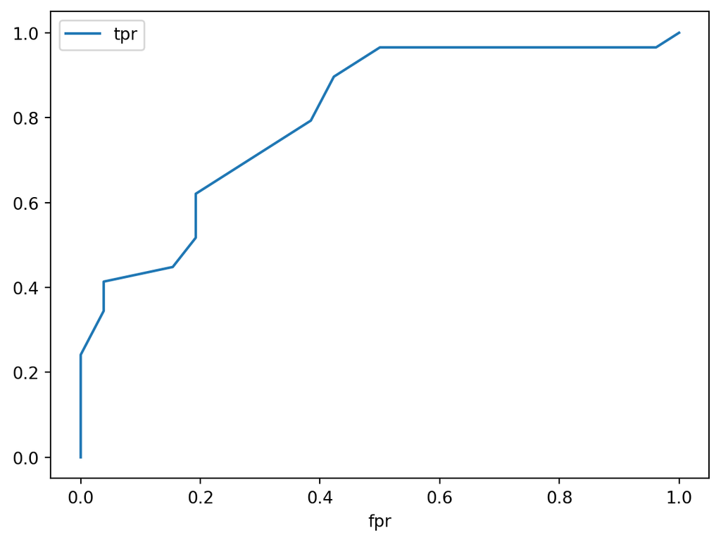

```python
pd.DataFrame({
    "fpr": fpr_knn,
    "tpr": tpr_knn
}).plot.line(x="fpr", y="tpr")
```

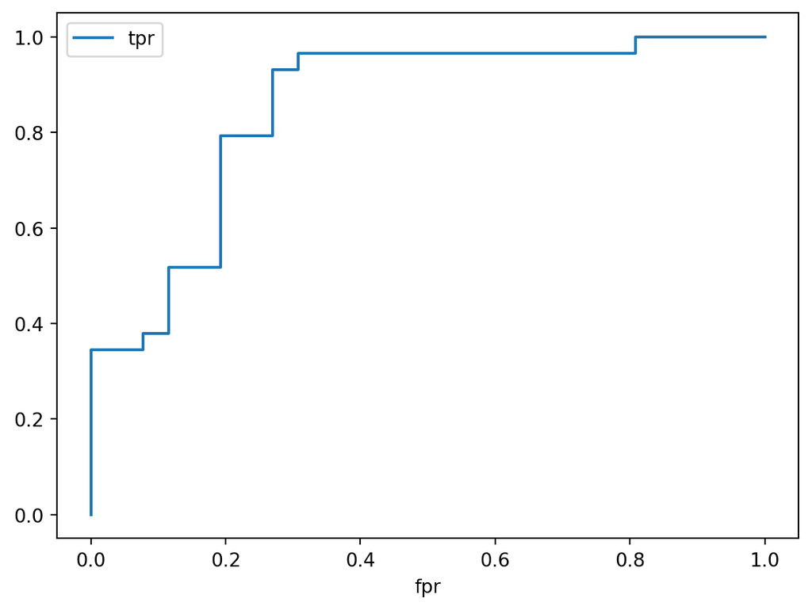

```python
pd.DataFrame({
    "fpr": fpr_lr,
    "tpr": tpr_lr
}).plot.line(x="fpr", y="tpr")
```

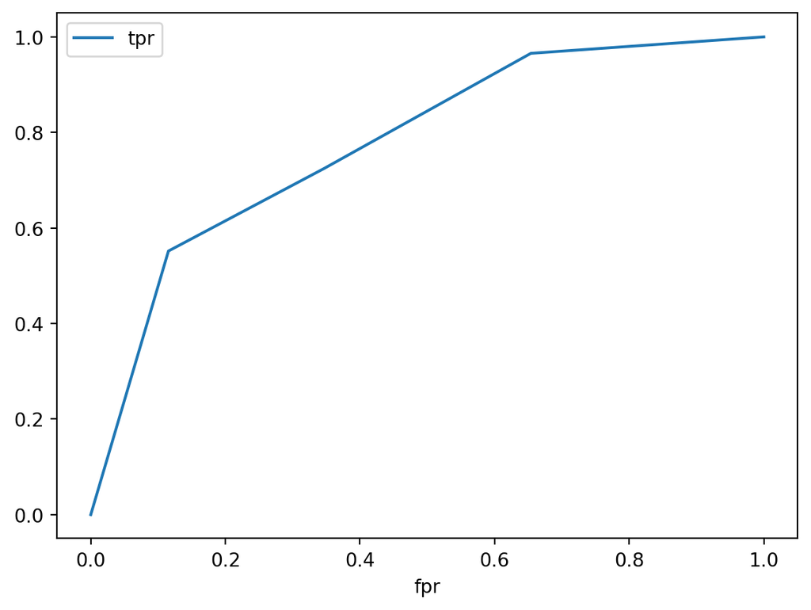

```python
pd.DataFrame({
    "fpr": fpr_dt,
    "tpr": tpr_dt
}).plot.line(x="fpr", y="tpr")
```

Part Two: Metrics Consider the following metrics: True Positive Rate or Recall or Sensitivity = Of the observations that are truly Class A, how many were predicted to be Class A? Precision or Positive Predictive Value = Of all the observations classified as Class A, how many of them were truly from Class A? True Negative Rate or Specificity or Negative Predictive Value = Of all the observations classified as NOT Class A, how many were truly NOT Class A? Compute each of these metrics (cross-validated) for your three models (KNN, Logistic Regression, and Decision Tree) in Part One.

```python
specificity_scorer = make_scorer(lambda y_true, y_pred: confusion_matrix(y_true, y_pred)[0, 0] / (confusion_matrix(y_true, y_pred)[0, 0] + confusion_matrix(y_true, y_pred)[0, 1]))
knn_recall = cross_val_score(best_knn, X_train, y_train, cv=5, scoring="recall")
knn_precision = cross_val_score(best_knn, X_train, y_train, cv=5, scoring="precision")
knn_specificity = cross_val_score(best_knn, X_train, y_train, cv=5, scoring=specificity_scorer)
lr_recall = cross_val_score(best_lr, X_train, y_train, cv=5, scoring="recall")
lr_precision = cross_val_score(best_lr, X_train, y_train, cv=5, scoring="precision")
lr_specificity = cross_val_score(best_lr, X_train, y_train, cv=5, scoring=specificity_scorer)
dt_recall = cross_val_score(best_dt, X_train, y_train, cv=5, scoring="recall")
dt_precision = cross_val_score(best_dt, X_train, y_train, cv=5, scoring="precision")
dt_specificity = cross_val_score(best_dt, X_train, y_train, cv=5, scoring=specificity_scorer)
pd.DataFrame({
    "Model": ["KNN", "Logistic Regression", "Decision Tree"],
    "Recall": [knn_recall.mean(), lr_recall.mean(), dt_recall.mean()],
    "Precision": [knn_precision.mean(), lr_precision.mean(), dt_precision.mean()],
    "Specificity": [knn_specificity.mean(), lr_specificity.mean(), dt_specificity.mean()]
})
```

|  | Model | Recall | Precision | Specificity |
| --- | --- | --- | --- | --- |
| 0 | KNN | 0.828261 | 0.750829 | 0.683810 |
| 1 | Logistic Regression | 0.810145 | 0.771889 | 0.723333 |
| 2 | Decision Tree | 0.775362 | 0.795223 | 0.762857 |

Part Three: Discussion Suppose you have been hired by a hospital to create classification models for heart attack risk. The following questions give a possible scenario for why the hospital is interested in these models. For each one, discuss: Which metric(s) you would use for model selection and why. Which of your final models (Part One Q1-3) you would recommend to the hospital, and why. What score you should expect for your chosen metric(s) using your chosen model to predict future observations.

Q3 The hospital is studying root causes of heart attacks, and would like to understand which biological measures are associated with heart attack risk. Coefficients because it shows relationships between predictors and outcomes Logistic regression because it provides coefficients for each feature 80%

Part Four: Validation Before sharing the dataset with you, I set aside a random 10% of the observations to serve as a final validation set. Use each of your final models in Part One Q1-3, predict the target variable in the validation dataset. For each, output a confusion matrix, and report the ROC AUC, the precision, and the recall. Compare these values to the cross-validated estimates you reported in Part One and Part Two. Did our measure of model success turn out to be approximately correct for the validation data?

```python
df_val = pd.read_csv("/Users/pinoliara/Downloads/GSB_544/Week_8/heart_attack_validation.csv")
X_val = df_val.drop("output", axis=1)
y_val = df_val["output"]
```

```python
y_pred_knn_val = best_knn.predict(X_val)
y_pred_lr_val = best_lr.predict(X_val)
y_pred_dt_val = best_dt.predict(X_val)
```

```python
cm_knn_val = confusion_matrix(y_val, y_pred_knn_val)
knn_recall_val = cm_knn_val[1, 1] / (cm_knn_val[1, 1] + cm_knn_val[1, 0])
knn_precision_val = cm_knn_val[1, 1] / (cm_knn_val[1, 1] + cm_knn_val[0, 1])
knn_specificity_val = cm_knn_val[0, 0] / (cm_knn_val[0, 0] + cm_knn_val[0, 1])
cm_lr_val = confusion_matrix(y_val, y_pred_lr_val)
lr_recall_val = cm_lr_val[1, 1] / (cm_lr_val[1, 1] + cm_lr_val[1, 0])
lr_precision_val = cm_lr_val[1, 1] / (cm_lr_val[1, 1] + cm_lr_val[0, 1])
lr_specificity_val = cm_lr_val[0, 0] / (cm_lr_val[0, 0] + cm_lr_val[0, 1])
cm_dt_val = confusion_matrix(y_val, y_pred_dt_val)
dt_recall_val = cm_dt_val[1, 1] / (cm_dt_val[1, 1] + cm_dt_val[1, 0])
dt_precision_val = cm_dt_val[1, 1] / (cm_dt_val[1, 1] + cm_dt_val[0, 1])
dt_specificity_val = cm_dt_val[0, 0] / (cm_dt_val[0, 0] + cm_dt_val[0, 1])
pd.DataFrame({
    "Model": ["KNN", "Logistic Regression", "Decision Tree"],
    "Recall": [knn_recall_val, lr_recall_val, dt_recall_val],
    "Precision": [knn_precision_val, lr_precision_val, dt_precision_val],
    "Specificity": [knn_specificity_val, lr_specificity_val, dt_specificity_val]
})
```

|  | Model | Recall | Precision | Specificity |
| --- | --- | --- | --- | --- |
| 0 | KNN | 0.894737 | 0.894737 | 0.818182 |
| 1 | Logistic Regression | 0.789474 | 0.937500 | 0.909091 |
| 2 | Decision Tree | 0.736842 | 0.933333 | 0.909091 |

```python
y_pred_proba_knn_val = best_knn.predict_proba(X_val)[:, 1]
y_pred_proba_lr_val = best_lr.predict_proba(X_val)[:, 1]
y_pred_proba_dt_val = best_dt.predict_proba(X_val)[:, 1]
knn_auc_val = roc_auc_score(y_val, y_pred_proba_knn_val)
lr_auc_val = roc_auc_score(y_val, y_pred_proba_lr_val)
dt_auc_val = roc_auc_score(y_val, y_pred_proba_dt_val)
```

```python
pd.DataFrame({
    "Model": ["KNN", "Logistic Regression", "Decision Tree"],
    "CV_ROC_AUC": [knn_cv_scores.mean(), lr_cv_scores.mean(), dt_cv_scores.mean()],
    "Val_ROC_AUC": [knn_auc_val, lr_auc_val, dt_auc_val],
    "CV_Recall": [knn_recall.mean(), lr_recall.mean(), dt_recall.mean()],
    "Val_Recall": [knn_recall_val, lr_recall_val, dt_recall_val],
    "CV_Precision": [knn_precision.mean(), lr_precision.mean(), dt_precision.mean()],
    "Val_Precision": [knn_precision_val, lr_precision_val, dt_precision_val],
    "CV_Specificity": [knn_specificity.mean(), lr_specificity.mean(), dt_specificity.mean()],
    "Val_Specificity": [knn_specificity_val, lr_specificity_val, dt_specificity_val]
})
```

|  | Model | CV_ROC_AUC | Val_ROC_AUC | CV_Recall | Val_Recall | CV_Precision | Val_Precision | CV_Specificity | Val_Specificity |
| --- | --- | --- | --- | --- | --- | --- | --- | --- | --- |
| 0 | KNN | 0.857487 | 0.906699 | 0.828261 | 0.894737 | 0.750829 | 0.894737 | 0.683810 | 0.818182 |
| 1 | Logistic Regression | 0.850986 | 0.937799 | 0.810145 | 0.789474 | 0.771889 | 0.937500 | 0.723333 | 0.909091 |
| 2 | Decision Tree | 0.775026 | 0.892344 | 0.775362 | 0.736842 | 0.795223 | 0.933333 | 0.762857 | 0.909091 |

Part Five: Cohen’s Kappa Another common metric used in classification is Cohen’s Kappa. Use online resources to research this measurement. Calculate it for the models from Part One, Q1-3, and discuss reasons or scenarios that would make us prefer to use this metric as our measure of model success. Do your conclusions from above change if you judge your models using Cohen’s Kappa instead? Does this make sense?

```python
cm_knn = confusion_matrix(y_test, y_pred_knn)
total_knn = cm_knn.sum()
observed_agreement_knn = (cm_knn[0, 0] + cm_knn[1, 1]) / total_knn
expected_agreement_knn = ((cm_knn[0, 0] + cm_knn[0, 1]) * (cm_knn[0, 0] + cm_knn[1, 0]) + (cm_knn[1, 0] + cm_knn[1, 1]) * (cm_knn[0, 1] + cm_knn[1, 1])) / (total_knn ** 2)
kappa_knn = (observed_agreement_knn - expected_agreement_knn) / (1 - expected_agreement_knn)
cm_lr = confusion_matrix(y_test, y_pred_lr)
total_lr = cm_lr.sum()
observed_agreement_lr = (cm_lr[0, 0] + cm_lr[1, 1]) / total_lr
expected_agreement_lr = ((cm_lr[0, 0] + cm_lr[0, 1]) * (cm_lr[0, 0] + cm_lr[1, 0]) + (cm_lr[1, 0] + cm_lr[1, 1]) * (cm_lr[0, 1] + cm_lr[1, 1])) / (total_lr ** 2)
kappa_lr = (observed_agreement_lr - expected_agreement_lr) / (1 - expected_agreement_lr)
cm_dt = confusion_matrix(y_test, y_pred_dt)
total_dt = cm_dt.sum()
observed_agreement_dt = (cm_dt[0, 0] + cm_dt[1, 1]) / total_dt
expected_agreement_dt = ((cm_dt[0, 0] + cm_dt[0, 1]) * (cm_dt[0, 0] + cm_dt[1, 0]) + (cm_dt[1, 0] + cm_dt[1, 1]) * (cm_dt[0, 1] + cm_dt[1, 1])) / (total_dt ** 2)
kappa_dt = (observed_agreement_dt - expected_agreement_dt) / (1 - expected_agreement_dt)
pd.DataFrame({
    "Model": ["KNN", "Logistic Regression", "Decision Tree"],
    "Cohen_Kappa": [kappa_knn, kappa_lr, kappa_dt],
    "ROC_AUC": [roc_auc_score(y_test, y_pred_proba_knn),
                roc_auc_score(y_test, y_pred_proba_lr),
                roc_auc_score(y_test, y_pred_proba_dt)]
})
```

|  | Model | Cohen_Kappa | ROC_AUC |
| --- | --- | --- | --- |
| 0 | KNN | 0.481132 | 0.803050 |
| 1 | Logistic Regression | 0.630872 | 0.852785 |
| 2 | Decision Tree | 0.378738 | 0.779178 |

The conclusions from above change don’t change. This makes sense because Cohen’s Kappa and ROC AUC measure overall model quality but in different ways